# Mapping with TIGER/FILE - Wisconsin

#### Note: this presentation relies on the work of Kyle Walker (https://www.github.com/walkerke) who developed the tigris and tidycensus package, it is adapted from the file linked at the bottom of this document.

#### loading packages

```r
library(tigris)
library(sf)
library(tidyverse)
options(tigris_class = "sf")
options(tigris_use_cache = TRUE)
```

### TIGER stands for Topologically Integrated Geographic Encoding and Referencing

TIGER was developed 30 years ago by the United States Census Bureau to as a tool to manage the 1990 decennial census. It has pretty much complete coverage of roads, rivers, lakes, and administrative, statistical and political boundaries. Unlike ArcGIS, its files are public domain which have spurred innovation by allowing MapQuest, OpenStreetMap and Google to build on its foundation.

A great way of taking advantage of this treasure trove of free files is the **tigris** R package developed by Kyle Walker.

TIGER/Line Shapefiles are available for these levels of geographical divisions (these are also the names of the functions for the **tigris** package):

##### Census statistical

- block_groups
- blocks
- combined_statistical_areas
- core_based_statistical_areas
- metro_divisions
- pumas (Public Use Microdata Area)
- tracts

##### Tribal/Native

- native_areas
- tribal_block_groups
- tribal_census_tracts
- tribal_subdivisions_national

##### Electoral

- congressional_districts
- state_legislative_districts
- voting_districts

##### Political boundaries

- counties
- county_subdivisions (i.e. incorporated cities, towns, townships)
- school_districts
- states

##### Postal

- zctas (Zip Code Tabulation Area)

The general syntax is

**tracts(state, county= NULL, cb = FALSE, year = NULL)**

- *state*: can be the two digit FIPS code, two-letter state abbreviation or name of the state.
- *county*: (subset of state): the three digit FIPS code for the county or its name or a vector of these for multiple counties
- *cb*: when set to TRUE - a generalized file, when set to FALSE - the most detailed TIGER/LINE file

TIGER/Line Shapefiles do not include demographic data, but they do contain geographic entity codes (GEOIDs) that can be linked to the Census Bureau’s demographic data, available on American FactFinder. (US Census Bureau)

We can get shapefiles of the states, the files are massive so I downloaded the state TIGER files ahead of time and extracted the row for Wisconsin and saved it as an Rdata file, since the file from the Census is about 10.9 Mb.

> stateshape <- states()

> wiscout <- filter(stateshape, grepl(“Wisconsin”, NAME))

> save(wiscout, file= "wiscout.Rda)

```r
load(file = "wiscout.Rda")
```

To get shapefiles of all the Census tracts in Wisconsin, we use the ‘tracts’ function from the tigris function and proceed to plot them

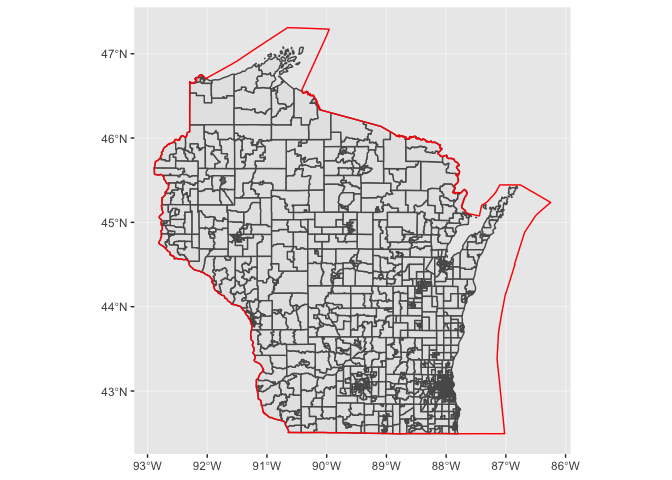

```r
wicensus <- tracts("WI", cb = TRUE)
ggplot() +
geom_sf(data=wicensus) +
geom_sf(data = wiscout, fill=NA, color="red")
```

#### Load the core based statistical area dataframe for the entire united states.

A **core based stateistical area** The general concept of a CBSA is that of a core area containing a substantial population nucleus, together with adjacent communities having a high degree of economic and social integration with that core.

```r
cb <- core_based_statistical_areas(cb = TRUE)
```

### Plot the entire set of core based statistical areas and include the Wisconsin shapefile for reference

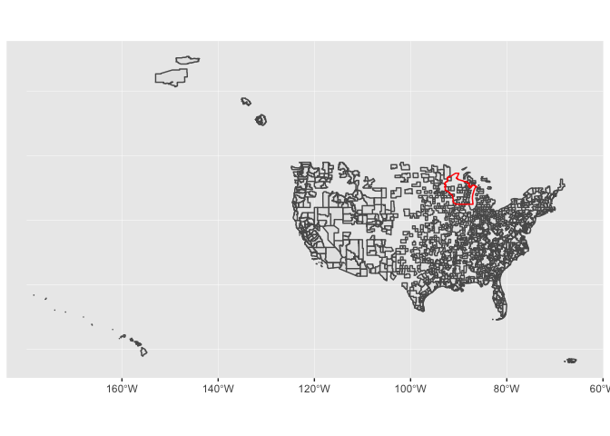

```r
ggplot() +
geom_sf(data=cb) +
geom_sf(data = wiscout, fill=NA, color="red")
```

#### select only the core based statistical areas for wisconsin and plot

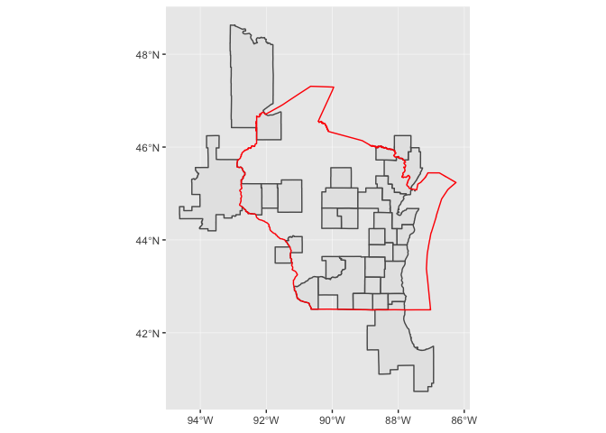

```r
wiscb <- filter(cb, grepl("WI", NAME))
ggplot() +
geom_sf(data=wiscb) +
geom_sf(data = wiscout, fill=NA, color="red")
```

#### Extract the core based statistical area that contains Madison.

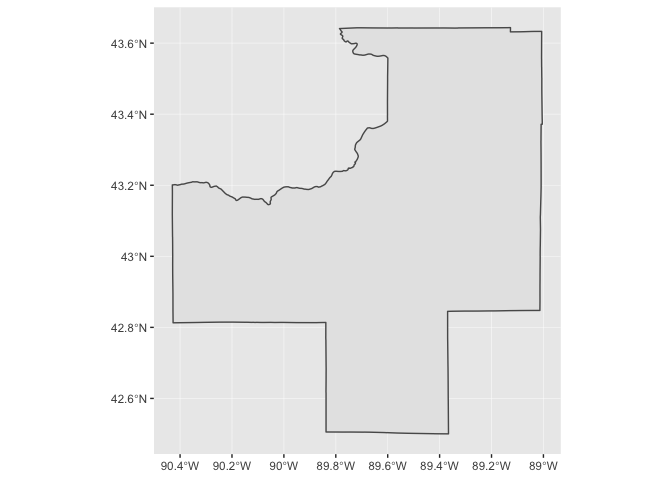

```r
madmetro <- filter(cb, grepl("Madison, WI", NAME))
ggplot(madmetro) + geom_sf()
```

#### subset the Madison core based statistical area within the Wisconsin census tract set

```r
p1 <- wicensus[madmetro,]
```

```
## although coordinates are longitude/latitude, st_intersects assumes that they are planar
```

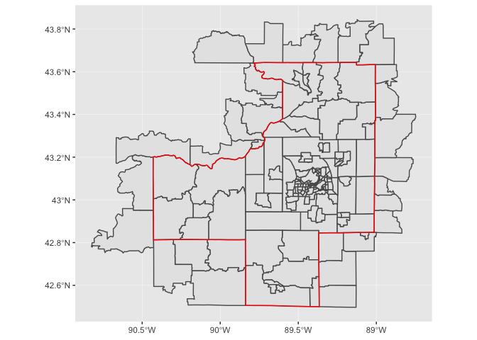

```r
ggplot() +
geom_sf(data = p1) +
geom_sf(data = madmetro, fill = NA, color = "red")
```

#### remove tracts that are outisde, generate a list of tracts inside integer(1) and outside integer(0)

```r
w1 <- st_within(wicensus, madmetro)
```

```
## although coordinates are longitude/latitude, st_within assumes that they are planar
```

```r
print(length(w1))
```

```
## [1] 1396
```

```r
print(w1[10:15])
```

```
## [[1]]
## [1] 1
##
## [[2]]
## [1] 1
##
## [[3]]
## [1] 1
##
## [[4]]
## [1] 1
##
## [[5]]
## integer(0)
##
## [[6]]
## integer(0)
```

#### we convert those that have integer(1) to a logical vector function by [Kyle Walker](https://www.github.com/walkerke)

```r
w2 <- map_lgl(w1, function(x) {
  if (length(x) == 1) {
    return(TRUE)
  } else {
    return(FALSE)
  }
})

print(w2[10:15])
```

```
## [1]  TRUE  TRUE  TRUE  TRUE FALSE FALSE
```

#### now we can exclude the Census tracts that fall outside this area

```r
p2 <- wicensus[w2,]
print(nrow(p2))
```

```
## [1] 133
```

#### and plot the results

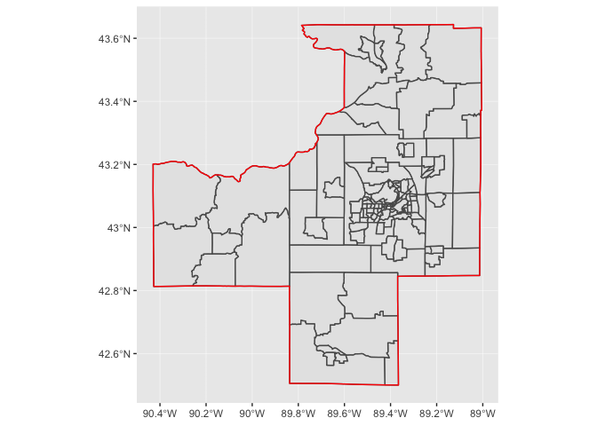

```r
ggplot() +
  geom_sf(data = p2) +
  geom_sf(data = madmetro, fill = NA, color = "red")
```

#### for more information go to https://walkerke.github.io/2017/05/tigris-metros/